# Preprocessing

## Import Libraries

```python
%matplotlib inline

import numpy as np
import pandas as pd
import scipy.ndimage
import matplotlib.pyplot as plt
import pydicom
import os
from skimage import measure, morphology
from mpl_toolkits.mplot3d.art3d import Poly3DCollection
import sys
import logging
import six
from radiomics import featureextractor, getFeatureClasses
import radiomics
from radiomics import featureextractor
import SimpleITK as sitk
import pylidc as pl
from pylidc.utils import consensus
from pylidc.utils import volume_viewer
```

## Data Preprocessing

### Exploring the LIDC-IDRI dataset

Load the metadata.csv and see what information can we get from it.

```python
metadata = pd.read_csv('metadata.csv')
metadata.head(1)
```

|  | Series UID | Collection | 3rd Party Analysis | Data Description URI | Subject ID | Study UID | Study Description | Study Date | Series Description | Manufacturer | Modality | SOP Class Name | SOP Class UID | Number of Images | File Size | File Location | Download Timestamp |
| --- | --- | --- | --- | --- | --- | --- | --- | --- | --- | --- | --- | --- | --- | --- | --- | --- | --- |
| 0 | 1.3.6.1.4.1.14519.5.2.1.6279.6001.493562949900... | LIDC-IDRI | NaN | https://doi.org/10.7937/K9/TCIA.2015.LO9QL9SX | LIDC-IDRI-0002 | 1.3.6.1.4.1.14519.5.2.1.6279.6001.116951808801... | NaN | 01-01-2000 | NaN | GE MEDICAL SYSTEMS | DX | Digital X-Ray Image Storage - For Presentation | 1.2.840.10008.5.1.4.1.1.1.1 | 1 | 6.91 MB | ./LIDC-IDRI/LIDC-IDRI-0002/01-01-2000-NA-NA-26... | 2023-10-05T12:40:37.146 |

```python
metadata.columns
```

```
Index(['Series UID', 'Collection', '3rd Party Analysis',
       'Data Description URI', 'Subject ID', 'Study UID', 'Study Description',
       'Study Date', 'Series Description', 'Manufacturer', 'Modality',
       'SOP Class Name', 'SOP Class UID', 'Number of Images', 'File Size',
       'File Location', 'Download Timestamp'],
      dtype='object')
```

Next, we start exploring the CT scans with the pydicom library. First we get the file location corresponding to the subject from some row of the metadata. Some folders have multiple dicom files which together form the whole CT image. We open a few of those .dcm files:

```python
dir = metadata.loc[2]['File Location']
dir
```

```
'./LIDC-IDRI/LIDC-IDRI-0001/01-01-2000-NA-NA-30178/3000566.000000-NA-03192'
```

```python
CT_folder = os.path.join(dir)
ct1 = pydicom.read_file(os.path.join(CT_folder, '1-001.dcm'))
ct2 = pydicom.read_file(os.path.join(CT_folder, '1-132.dcm'))
image1 = ct1.pixel_array
image2 = ct2.pixel_array
```

The images are 2D arrays. Typically the pixel values are stored in a scaled format so we should adjust them back to Houndsfield units:

```python
image1 = ct1.RescaleSlope * image1 + ct1.RescaleIntercept
image2 = ct2.RescaleSlope * image2 + ct2.RescaleIntercept
```

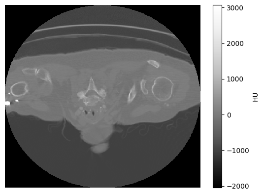

```python
plt.pcolormesh(image1, cmap='Greys_r')
plt.colorbar(label='HU')
plt.axis('off')
plt.show()
```

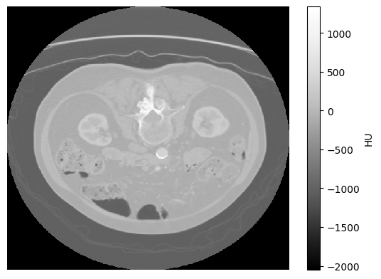

```python
plt.pcolormesh(image2, cmap='Greys_r')
plt.colorbar(label='HU')
plt.axis('off')
plt.show()
```

### Exploring pylidc library

We begin exploring with the pylidc library, which is made for working with LIDC dataset. This library will be the basis of our work.

First we load all scans from the pylidc.Scan class, which holds some of the DICOM attributes associated with the CT scans in the LIDC dataset. And also all the annotations from the XML files.

```python
scans = pl.query(pl.Scan).all()
```

```python
annotations = pl.query(pl.Annotation).all()
```

We are going to take the a random scan try to visualize it using pylidc methods.

```python
scan = scans[4]
print(scan.patient_id)
```

```
LIDC-IDRI-0110
```

Each scan has multiple annotations refering to different nodules. We use the cluster_annotations() method to estimate which annotations refer to the same nodule in the CT scan.

```python
nods = scan.cluster_annotations()
```

Now we can visualize the scan along with important informations about the nodules:

```
Loading dicom files ... This may take a moment.
```

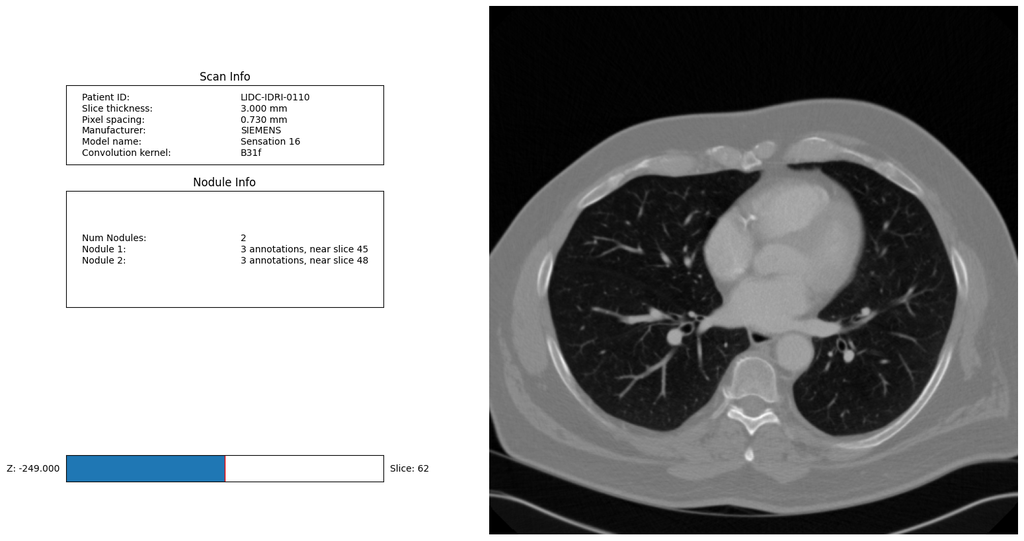

```python
scan.visualize(annotation_groups=nods)
```

The annotation class also has some methods visualize the scan with respect to the nodules. In this case we take two annotations from the same patient and analyse that they refer to two different nodules:

```python
ann1 = annotations[0]
ann2 = annotations[1]
```

```
Loading dicom files ... This may take a moment.
```

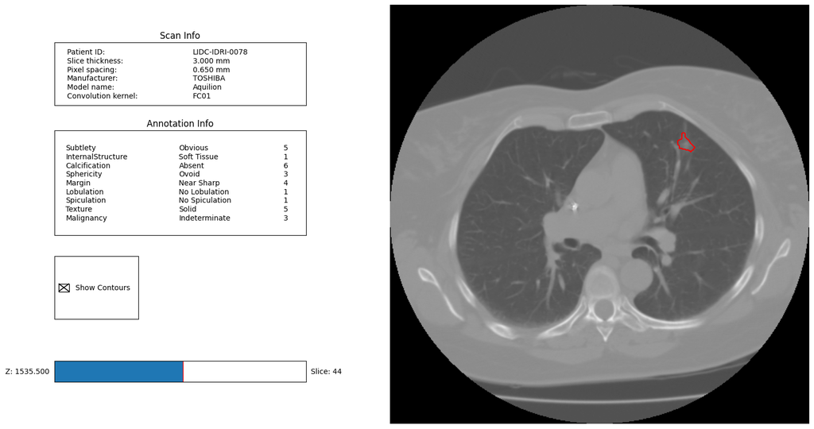

```python
ann1.visualize_in_scan()
```

```
Loading dicom files ... This may take a moment.
```

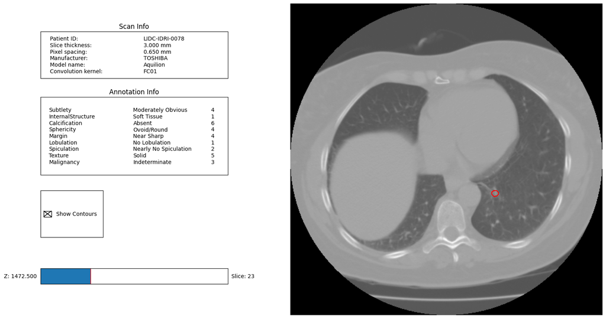

```python
ann2.visualize_in_scan()
```

Next, we use visualize both nodules in 3d:

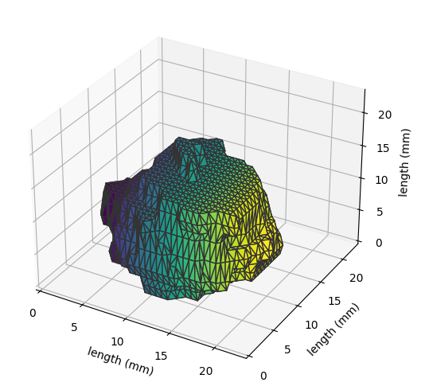

```python
ann1.visualize_in_3d()
```

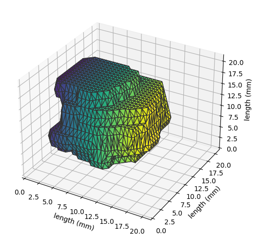

```python
ann2.visualize_in_3d()
```

After exploring our data, seeing how to get images from the CT scan slices and how to get information about the various nodules, we need start thinking about feature extraction. For that purpose, we can take some features directly out of pylidc but we also want to extract features with the pyradiomics library.

### Creating a Mask

To extract features from pyradiomics, we need to create a mask.

```python
# Return the scan as a 3D numpy array volume.
ann = annotations[0]
vol = ann.scan.to_volume()
```

```
Loading dicom files ... This may take a moment.
```

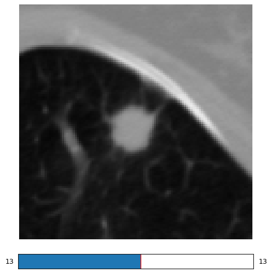

```python
padding = 70.0
bbox = ann.bbox(pad=padding)
volume_viewer(vol[bbox])
```

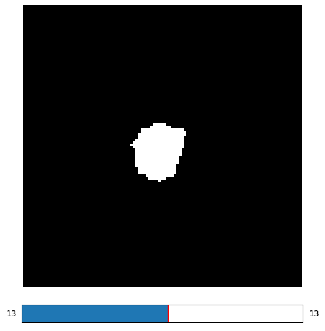

```python
mask = ann.boolean_mask(pad = padding)
volume_viewer(mask)
```

### Extracting the Features and Creating the Dataframe

Now we can start extracting some features and inserting them in a dataframe.

To do that, we created some functions:

```python
def ann_row(ann):
    ids = np.array([ann.scan.patient_id, ann.id, ann.scan_id], dtype = '<U14')
    others = np.array([ann.diameter,ann.surface_area, ann.volume])
    features = ann.feature_vals()
    return(ids, others, features)
```

```python
def anns_df(anotacoes):
    # Make sure that we are working with a list
    if  not isinstance(anotacoes, list):
        anotacoes = [anotacoes]

    # Create 3 dataframes:
    df_id = pd.DataFrame(columns = ["Patient_id", "Annotation_id", "Scan_id"])
    df_others =pd.DataFrame(columns = ["Diameter", "SurfaceArea", "Volume"])
    df_feat = pd.DataFrame(columns=['Subtlety', 'Internalstructure', 'Calcification','Sphericity','Margin','Lobulation',
                           'Spiculation','Texture','Malignancy'])

    #JOin the 3 dataframes in one single dataframe:
    for i, ann in enumerate(anotacoes):
        array_id,array_other, array_feat = ann_row(ann)
        df_id.loc[i] = array_id
        df_others.loc[i] = array_other
        df_feat.loc[i] = array_feat

    df = pd.concat([df_id, df_others], axis = 1)
    df1 = pd.concat([df, df_feat], axis = 1)
    return(df1)
```

```python
def id_nodulo(scans):
    nodulos = pd.DataFrame(columns = ['Nodule_Id', 'Patient_id', 'Annotation_id', 'Scan_id'])
    i = 1
    j = 0
    for scan in scans:
        patient = scan.patient_id
        nods = scan.cluster_annotations()
        for anns in nods:
            for ann in anns:
                lista = []
                lista.append(i)
                lista.append(patient)
                lista.append(ann.id)
                lista.append(ann.scan_id)
                nodulos.loc[j] = lista
                j = j+1
            i = i+1
    return(nodulos)
```

```python
def juntar(df1, df2):
    #df1 = annotations
    #df2 = nodules
    df = df1.merge(df2[['Patient_id', 'Annotation_id', 'Scan_id', 'Nodule_Id']],
                    on=['Patient_id', 'Annotation_id', 'Scan_id'], how='left')
    ordem_colunas = [df.columns[0], 'Nodule_Id'] + list(df.columns[1:-1]) #Reorder the columns
    df = df[ordem_colunas]
    return(df)
```

```python
def cluster(df):
    # Remove some id columns and group all annotations based on their respetive nodules
    df1 = df.drop(['Patient_id', 'Annotation_id'], axis=1)
    group = df1.groupby('Nodule_Id').mean().reset_index()

    #Add the 'Patient_id' column
    df2 = df[['Patient_id', 'Nodule_Id']]
    df2 = df2.sort_values(by='Nodule_Id', ascending=True, ignore_index=True) # Ordering Nodule_id by ascending order
    df2 = df2.drop_duplicates(subset='Nodule_Id')  # Getting only one row for each nodule
    df2 = df2.reset_index(drop=True) # Redefine the dataframe columns

    group['Patient_id'] = df2['Patient_id']
    ordem_colunas = ['Patient_id'] + list(group.columns[0:-1]) #Reorder the columns
    group = group[ordem_colunas]
    group['Scan_id'] = group['Scan_id'].astype(int) # float to int

    return(group)
```

These functions were made to create a dataframe with the features that we can extract directly from the pylidc library.

- First, we create the function 'ann_row' which takes an annotation and gathers a bunch of attributes useful for classification.
- Next, we use the the 'anns_df' function to go through all the annotations, extract the features of each one with the preavious function and create a dataframe with the results.
- Then we create the 'id_nodulo' function that takes all the scans, uses the cluster_annotations method for each scan to identify every single nodule in the dataset (based on the annotations).
- After that, we need to use 'juntar' to join the two dataframes created with 'anns_df' and 'id_nodule'. That way, every annotation is associated with a nodule.

We get this dataframe as a result:

```python
df =  pd.read_csv('pylidc_nod.csv')
df.head(5)
```

|  | Patient_id | Nodule_Id | Annotation_id | Scan_id | Diameter | SurfaceArea | Volume | Subtlety | Internalstructure | Calcification | Sphericity | Margin | Lobulation | Spiculation | Texture | Malignancy |
| --- | --- | --- | --- | --- | --- | --- | --- | --- | --- | --- | --- | --- | --- | --- | --- | --- |
| 0 | LIDC-IDRI-0078 | 2 | 1 | 1 | 20.840585 | 1124.125177 | 2439.30375 | 5 | 1 | 6 | 3 | 4 | 1 | 1 | 5 | 3 |
| 1 | LIDC-IDRI-0078 | 1 | 2 | 1 | 19.500000 | 1135.239277 | 2621.82375 | 4 | 1 | 6 | 4 | 4 | 1 | 2 | 5 | 3 |
| 2 | LIDC-IDRI-0078 | 4 | 3 | 1 | 23.300483 | 1650.898027 | 4332.31500 | 5 | 1 | 4 | 3 | 5 | 2 | 3 | 5 | 4 |
| 3 | LIDC-IDRI-0078 | 4 | 4 | 1 | 32.810517 | 1994.684094 | 5230.33875 | 5 | 1 | 6 | 4 | 2 | 4 | 1 | 5 | 5 |
| 4 | LIDC-IDRI-0078 | 2 | 5 | 1 | 20.891206 | 1130.172711 | 2443.74000 | 4 | 1 | 6 | 4 | 2 | 3 | 1 | 4 | 4 |

- The last function 'cluster' takes the dataframe created with the previous functions and groups all the annotations by nodule_id. To do that, we need to remove the 'Annotation_id' column and calculate the mean of all annotations that refer to the same nodule.

```python
df1 =  pd.read_csv('pylidc_grouped.csv')
df1.head()
```

|  | Patient_id | Nodule_Id | Scan_id | Diameter | SurfaceArea | Volume | Subtlety | Internalstructure | Calcification | Sphericity | Margin | Lobulation | Spiculation | Texture | Malignancy |
| --- | --- | --- | --- | --- | --- | --- | --- | --- | --- | --- | --- | --- | --- | --- | --- |
| 0 | LIDC-IDRI-0078 | 1 | 1 | 23.945243 | 1193.424473 | 2516.304375 | 4.50 | 1.0 | 6.0 | 4.00 | 3.25 | 2.25 | 2.25 | 4.75 | 3.75 |
| 1 | LIDC-IDRI-0078 | 2 | 1 | 20.694395 | 1018.748994 | 2193.250312 | 4.75 | 1.0 | 6.0 | 4.00 | 2.75 | 3.00 | 2.25 | 4.50 | 3.75 |
| 2 | LIDC-IDRI-0078 | 3 | 1 | 5.076662 | 66.910605 | 62.107500 | 4.00 | 1.0 | 5.0 | 5.00 | 5.00 | 1.00 | 1.00 | 5.00 | 1.00 |
| 3 | LIDC-IDRI-0078 | 4 | 1 | 27.694350 | 1870.264307 | 4870.685625 | 5.00 | 1.0 | 5.0 | 3.75 | 3.25 | 3.25 | 2.75 | 4.75 | 4.25 |
| 4 | LIDC-IDRI-0069 | 5 | 2 | 12.648800 | 401.426716 | 585.183076 | 2.50 | 1.0 | 6.0 | 4.50 | 4.25 | 4.00 | 4.00 | 4.75 | 3.25 |

After extracting features from pylidc, we need to use to extract images using pyradiomics. To use pyradiomics, we need to activate the feature extractor first:

```python
#Alternative: use hardcoded settings (separate for settings, input image types and enabled features)
settings = {}
settings['binWidth'] = 25
settings['resampledPixelSpacing'] = None
# settings['resampledPixelSpacing'] = [3, 3, 3]  # This is an example for defining resampling (voxels with size 3x3x3mm)
settings['interpolator'] = 'sitkBSpline'
settings['verbose'] = True

extractor = featureextractor.RadiomicsFeatureExtractor(**settings)
```

Next we create the following function that takes all the scans, creates a mask for each nodule using consensus (which based on all annotations related to a nodule, creates a consensus of where the nodule, our ROI, will be), extracts the pyradiomics features for every nodule and returns a dataframe.

```python
def features_to_dataframe(scans):

    listafeatures = []
    df1 = pd.DataFrame(columns = ['Patient_id'])
    i=0

    for scan in scans:
        nods = scan.cluster_annotations()
        for anns in nods:
            vol = anns[0].scan.to_volume()
            df1.loc[i]=scan.patient_id

            # Perform a consensus consolidation and achieve a 50% agreement level.
            cmask, cbbox, masks = consensus(anns, clevel=0.5, pad=[(20, 20), (20, 20), (0, 0)])
            cimage = vol[cbbox]

            # Convert the pixel matrix to a SimpleITK image.
            mask = sitk.GetImageFromArray(cmask.astype(float))
            image = sitk.GetImageFromArray(cimage.astype(float))

            #Extract the features
            features = extractor.execute(image, mask)
            listafeatures.append(features)

            i = i+1

    df1['Nodule_Id'] = range(1, len(df1) + 1)
    df2 = pd.DataFrame(listafeatures)
    df = pd.concat([df1, df2], axis = 1)
    return(df)
```

The result is the following dataframe, with the following columns:

```python
df2 = pd.read_csv('pyradiomics.csv')
df2.head()
```

|  | Patient_id | Nodule_Id | diagnostics_Versions_PyRadiomics | diagnostics_Versions_Numpy | diagnostics_Versions_SimpleITK | diagnostics_Versions_PyWavelet | diagnostics_Versions_Python | diagnostics_Configuration_Settings | diagnostics_Configuration_EnabledImageTypes | diagnostics_Image-original_Hash | ... | original_glszm_SmallAreaHighGrayLevelEmphasis | original_glszm_SmallAreaLowGrayLevelEmphasis | original_glszm_ZoneEntropy | original_glszm_ZonePercentage | original_glszm_ZoneVariance | original_ngtdm_Busyness | original_ngtdm_Coarseness | original_ngtdm_Complexity | original_ngtdm_Contrast | original_ngtdm_Strength |
| --- | --- | --- | --- | --- | --- | --- | --- | --- | --- | --- | --- | --- | --- | --- | --- | --- | --- | --- | --- | --- | --- |
| 0 | LIDC-IDRI-0078 | 1 | v3.0.1 | 1.19.5 | 2.3.0 | 1.4.1 | 3.9.18 | {'minimumROIDimensions': 2, 'minimumROISize': ... | {'Original': {}} | 8216beb893d3b2269e3b18733b1dc665c6df68f0 | ... | 178.400070 | 0.005986 | 6.010819 | 0.334735 | 260.979434 | 0.493585 | 0.002822 | 1137.306597 | 0.307651 | 1.322429 |
| 1 | LIDC-IDRI-0078 | 2 | v3.0.1 | 1.19.5 | 2.3.0 | 1.4.1 | 3.9.18 | {'minimumROIDimensions': 2, 'minimumROISize': ... | {'Original': {}} | 85ad39e16e1b0a4105b2ca8fa05877f6907b606c | ... | 275.075306 | 0.005361 | 6.401714 | 0.403217 | 85.830799 | 0.287281 | 0.003877 | 2026.081170 | 0.514515 | 2.229384 |
| 2 | LIDC-IDRI-0078 | 3 | v3.0.1 | 1.19.5 | 2.3.0 | 1.4.1 | 3.9.18 | {'minimumROIDimensions': 2, 'minimumROISize': ... | {'Original': {}} | fce05221ab4895d08d89da192079558b41c3ce4d | ... | 441.393939 | 0.045317 | 4.453189 | 0.970588 | 0.029385 | 0.060377 | 0.059139 | 4045.202512 | 5.266028 | 40.460080 |
| 3 | LIDC-IDRI-0078 | 4 | v3.0.1 | 1.19.5 | 2.3.0 | 1.4.1 | 3.9.18 | {'minimumROIDimensions': 2, 'minimumROISize': ... | {'Original': {}} | 00bcb291df78ef3b5e369f1bcdd55aad81714cce | ... | 190.260718 | 0.008445 | 6.080622 | 0.291004 | 794.364708 | 0.559072 | 0.001781 | 1203.784476 | 0.153285 | 0.975385 |
| 4 | LIDC-IDRI-0069 | 5 | v3.0.1 | 1.19.5 | 2.3.0 | 1.4.1 | 3.9.18 | {'minimumROIDimensions': 2, 'minimumROISize': ... | {'Original': {}} | 7dbba23ab3a86ec62f5e5d3bab48c370589307fb | ... | 120.367848 | 0.027714 | 5.757455 | 0.497121 | 9.131140 | 0.195039 | 0.013582 | 1212.572882 | 0.380818 | 3.865897 |

5 rows × 131 columns

Our last step is removing some columns that are not useful for our model and joining the new dataframe with the pylidc features dataframe:

```python
# List of useless columns
list = df2.columns
list = list[2:25]
list
```

```
Index(['diagnostics_Versions_PyRadiomics', 'diagnostics_Versions_Numpy',
       'diagnostics_Versions_SimpleITK', 'diagnostics_Versions_PyWavelet',
       'diagnostics_Versions_Python', 'diagnostics_Configuration_Settings',
       'diagnostics_Configuration_EnabledImageTypes',
       'diagnostics_Image-original_Hash',
       'diagnostics_Image-original_Dimensionality',
       'diagnostics_Image-original_Spacing', 'diagnostics_Image-original_Size',
       'diagnostics_Image-original_Mean', 'diagnostics_Image-original_Minimum',
       'diagnostics_Image-original_Maximum', 'diagnostics_Mask-original_Hash',
       'diagnostics_Mask-original_Spacing', 'diagnostics_Mask-original_Size',
       'diagnostics_Mask-original_BoundingBox',
       'diagnostics_Mask-original_VoxelNum',
       'diagnostics_Mask-original_VolumeNum',
       'diagnostics_Mask-original_CenterOfMassIndex',
       'diagnostics_Mask-original_CenterOfMass', 'original_shape_Elongation'],
      dtype='object')
```

```python
# Removing the columns and joining our dataframe with the pylidc_grouped dataframe
df3 = df2.drop(columns=list)
dataframe = df3.merge(df1, on=['Patient_id','Nodule_Id'], how='left')
```

The final dataframe:

```python
dataframe = pd.read_csv('dataset.csv')
dataframe.head()
```

|  | Patient_id | Nodule_Id | original_shape_Flatness | original_shape_LeastAxisLength | original_shape_MajorAxisLength | original_shape_Maximum2DDiameterColumn | original_shape_Maximum2DDiameterRow | original_shape_Maximum2DDiameterSlice | original_shape_Maximum3DDiameter | original_shape_MeshVolume | ... | Volume | Subtlety | Internalstructure | Calcification | Sphericity | Margin | Lobulation | Spiculation | Texture | Malignancy |
| --- | --- | --- | --- | --- | --- | --- | --- | --- | --- | --- | --- | --- | --- | --- | --- | --- | --- | --- | --- | --- | --- |
| 0 | LIDC-IDRI-0078 | 1 | 0.219031 | 5.542891 | 25.306411 | 24.020824 | 39.051248 | 26.000000 | 41.509035 | 1874.625000 | ... | 2516.304375 | 4.50 | 1.0 | 6.0 | 4.00 | 3.25 | 2.25 | 2.25 | 4.75 | 3.75 |
| 1 | LIDC-IDRI-0078 | 2 | 0.215045 | 5.209030 | 24.222923 | 30.016662 | 31.064449 | 23.021729 | 31.064449 | 1717.416667 | ... | 2193.250312 | 4.75 | 1.0 | 6.0 | 4.00 | 2.75 | 3.00 | 2.25 | 4.50 | 3.75 |
| 2 | LIDC-IDRI-0078 | 3 | 0.289526 | 1.632763 | 5.639429 | 6.000000 | 6.324555 | 5.099020 | 6.324555 | 29.291667 | ... | 62.107500 | 4.00 | 1.0 | 5.0 | 5.00 | 5.00 | 1.00 | 1.00 | 5.00 | 1.00 |
| 3 | LIDC-IDRI-0078 | 4 | 0.216692 | 6.435946 | 29.700850 | 37.054015 | 43.566042 | 35.227830 | 49.284886 | 3610.791667 | ... | 4870.685625 | 5.00 | 1.0 | 5.0 | 3.75 | 3.25 | 3.25 | 2.75 | 4.75 | 4.25 |
| 4 | LIDC-IDRI-0069 | 5 | 0.595806 | 7.374952 | 12.378110 | 15.524175 | 14.142136 | 12.041595 | 15.588457 | 506.541667 | ... | 585.183076 | 2.50 | 1.0 | 6.0 | 4.50 | 4.25 | 4.00 | 4.00 | 4.75 | 3.25 |

5 rows × 121 columns